# A quick tour of mclust

# Using colorblind-friendly palettes

Most of the graphs produced by **mclust** use colors that by default are defined in the following options:

```r
mclust.options("bicPlotColors")
```

```
##       EII       VII       EEI       EVI       VEI       VVI       EEE       VEE
##    "gray"   "black" "#218B21" "#41884F" "#508476" "#58819C" "#597DC3" "#5178EA"
##       EVE       VVE       EEV       VEV       EVV       VVV         E         V
## "#716EE7" "#9B60B8" "#B2508B" "#C03F60" "#C82A36" "#CC0000"    "gray"   "black"
```

```r
mclust.options("classPlotColors")
```

```
##  [1] "dodgerblue2"    "red3"           "green3"         "slateblue"
##  [5] "darkorange"     "skyblue1"       "violetred4"     "forestgreen"
##  [9] "steelblue4"     "slategrey"      "brown"          "black"
## [13] "darkseagreen"   "darkgoldenrod3" "olivedrab"      "royalblue"
## [17] "tomato4"        "cyan2"          "springgreen2"
```

The first option controls colors used for plotting BIC, ICL, etc. curves, whereas the second option is used to assign colors for indicating clusters or classes when plotting data.

```r
palette.colors(palette = "Okabe-Ito")
```

```r
cbPalette <- c("#000000", "#E69F00", "#56B4E9", "#009E73", "#F0E442", "#0072B2",
"#D55E00", "#CC79A7", "#999999")
```

and then assigned to the **mclust** options as follows:

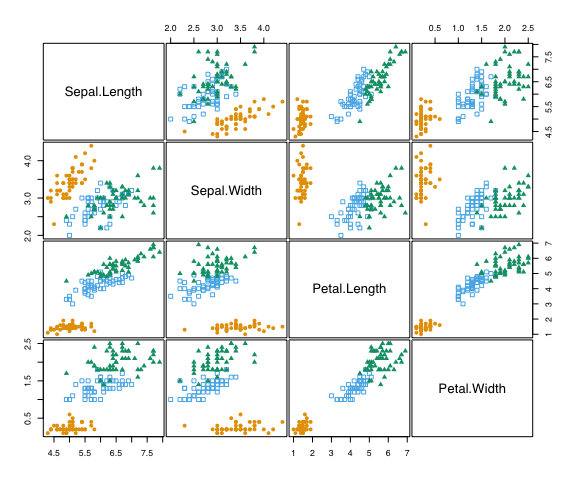

```r
bicPlotColors <- mclust.options("bicPlotColors")
bicPlotColors[1:14] <- c(cbPalette, cbPalette[1:5])
mclust.options("bicPlotColors" = bicPlotColors)
mclust.options("classPlotColors" = cbPalette[-1])

clPairs(iris[,-5], iris$Species)
```

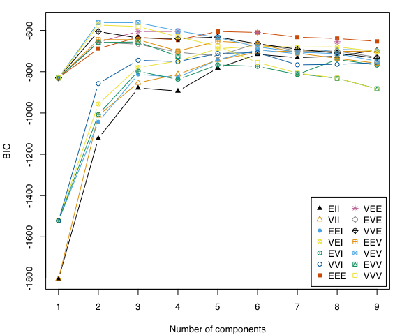

```r
mod <- Mclust(iris[,-5])
plot(mod, what = "BIC")
```

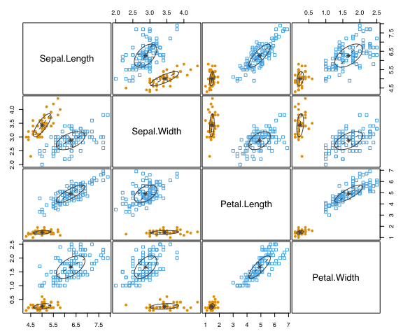

```r
plot(mod, what = "classification")
```

If needed, users can easily define their own palettes following the same procedure outlined above.

# References

Scrucca L., Fraley C., Murphy T. B. and Raftery A. E. (2023) *Model-Based Clustering, Classification, and Density Estimation Using mclust in R*. Chapman & Hall/CRC, ISBN: 978-1032234953, https://mclust-org.github.io/book/

Scrucca L., Fop M., Murphy T. B. and Raftery A. E. (2016) mclust 5: clustering, classification and density estimation using Gaussian finite mixture models, *The R Journal*, 8/1, pp. 205-233. https://journal.r-project.org/articles/RJ-2016-021/RJ-2016-021.pdf

Fraley C. and Raftery A. E. (2002) Model-based clustering, discriminant analysis and density estimation, *Journal of the American Statistical Association*, 97/458, pp. 611-631.